# Kaggle Project Report

### Boosting

```r
library(gbm)
set.seed(617)
trControl_boost6 = trainControl(method = 'cv', number = 5)  ## use 5-fold cross validation
tuneGrid_boost6 = expand.grid(n.trees = 200, interaction.depth = c(3,4,5),
                              shrinkage = c(0.005, 0.001, 0.01), n.minobsinnode = c(5,10,15))
## after trying different values of parameters, I found these values are the best according to the cross-validation results

cvBoost6 = train(price ~ price_mean_c + new_neigh_c + price_mean_gc + bedrooms + cleaning_fee + room_type + minimum_nights
               + accommodates + property_type + bathrooms + beds + neighbourhood_group_cleansed + host_is_superhost
               + security_deposit + availability_30 + availability_365 + review_scores_rating + availability_60
               + transit_wc + summary_wc+ description_wc+ host_since_days + reviews_per_month + cancellation_policy
               + last_review_days + first_review_days + extra_people + guests_included + availability_90
               + Airconditioning + Dryer + Elevator + Family_and_kidfriendly + Freestreetparking
               + review_scores_cleanliness + Hairdryer + Iron + Oven + Refrigerator + Shampoo + number_of_reviews
               + host_about_wc + Selfcheck_in  + TV + selfie + kba + jumio + maximum_nights + host_listings_count
               + neighborhood_overview_wc + host_has_profile_pic + monthly_price + review_scores_accuracy
               ,data = train, method = 'gbm', trControl = trControl_boost6, tuneGrid = tuneGrid_boost6)
```

```r
cvBoost6
```

```
## Stochastic Gradient Boosting
##
## 25819 samples
##    53 predictor
##
## No pre-processing
## Resampling: Cross-Validated (5 fold)
## Summary of sample sizes: 20656, 20655, 20655, 20655, 20655
## Resampling results across tuning parameters:
##
##   shrinkage  interaction.depth  n.minobsinnode  RMSE      Rsquared   MAE
##   0.001      3                   5              99.98831  0.5148155  66.81072
##   0.001      3                  10              99.98838  0.5162537  66.81016
##   0.001      3                  15              99.98064  0.5163901  66.81057
##   0.001      4                   5              99.25586  0.5420391  66.16655
##   0.001      4                  10              99.26136  0.5396990  66.15665
##   0.001      4                  15              99.25890  0.5401188  66.17562
##   0.001      5                   5              98.71656  0.5509394  65.79749
##   0.001      5                  10              98.70515  0.5494782  65.77866
##   0.001      5                  15              98.71216  0.5504468  65.77476
##   0.005      3                   5              81.65538  0.5776175  51.78504
##   0.005      3                  10              81.65333  0.5770530  51.75696
##   0.005      3                  15              81.62551  0.5773457  51.77968
##   0.005      4                   5              79.78318  0.5932945  50.38926
##   0.005      4                  10              79.82049  0.5919996  50.40784
##   0.005      4                  15              79.79619  0.5922511  50.39824
##   0.005      5                   5              78.52662  0.6036954  49.59361
##   0.005      5                  10              78.52114  0.6026115  49.57548
##   0.005      5                  15              78.54217  0.6020224  49.57422
##   0.010      3                   5              71.92362  0.6087168  44.27136
##   0.010      3                  10              71.97571  0.6080253  44.25751
##   0.010      3                  15              71.90743  0.6083825  44.24120
##   0.010      4                   5              70.19226  0.6213050  43.07897
##   0.010      4                  10              70.15739  0.6212158  43.01610
##   0.010      4                  15              70.20534  0.6190739  43.01146
##   0.010      5                   5              68.90064  0.6316684  42.28752
##   0.010      5                  10              68.96334  0.6305863  42.27373
##   0.010      5                  15              69.00189  0.6287949  42.22186
##
## Tuning parameter 'n.trees' was held constant at a value of 200
## RMSE was used to select the optimal model using the smallest value.
## The final values used for the model were n.trees = 200, interaction.depth =
##  5, shrinkage = 0.01 and n.minobsinnode = 5.
```

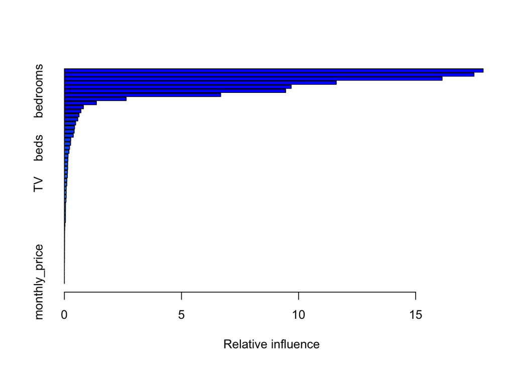

```
##                                                       var      rel.inf
## room_type                                       room_type 17.882924724
## accommodates                                 accommodates 17.491424832
## price_mean_c                                 price_mean_c 16.131270073
## bathrooms                                       bathrooms 11.612623476
## cleaning_fee                                 cleaning_fee  9.686434154
## bedrooms                                         bedrooms  9.448566822
## new_neigh_c                                   new_neigh_c  6.674975054
## property_type                               property_type  2.640191379
## minimum_nights                             minimum_nights  1.367957392
## guests_included                           guests_included  0.812528499
## availability_90                           availability_90  0.705272022
## Elevator                                         Elevator  0.625854437
## extra_people                                 extra_people  0.572664694
## availability_365                         availability_365  0.480725834
## review_scores_rating                 review_scores_rating  0.434842636
## Dryer                                               Dryer  0.417222386
## last_review_days                         last_review_days  0.380045971
## reviews_per_month                       reviews_per_month  0.269910657
## transit_wc                                     transit_wc  0.264212428
## beds                                                 beds  0.221859154
## review_scores_cleanliness       review_scores_cleanliness  0.195689539
## host_listings_count                   host_listings_count  0.155944308
## security_deposit                         security_deposit  0.149995689
## host_about_wc                               host_about_wc  0.141088089
## neighborhood_overview_wc         neighborhood_overview_wc  0.140532721
## summary_wc                                     summary_wc  0.131507627
## maximum_nights                             maximum_nights  0.126473242
## availability_60                           availability_60  0.105074475
## TV                                                     TV  0.102291414
## host_since_days                           host_since_days  0.078963423
## number_of_reviews                       number_of_reviews  0.078141728
## first_review_days                       first_review_days  0.077510151
## availability_30                           availability_30  0.066768772
## description_wc                             description_wc  0.048306781
## cancellation_policy                   cancellation_policy  0.047211247
## neighbourhood_group_cleansed neighbourhood_group_cleansed  0.046554873
## Shampoo                                           Shampoo  0.045817619
## price_mean_gc                               price_mean_gc  0.044695753
## Oven                                                 Oven  0.022794137
## host_is_superhost                       host_is_superhost  0.015866269
## Family_and_kidfriendly             Family_and_kidfriendly  0.010595526
## review_scores_accuracy             review_scores_accuracy  0.009001926
## jumio                                               jumio  0.008930697
## Selfcheck_in                                 Selfcheck_in  0.007981053
## kba                                                   kba  0.007132831
## selfie                                             selfie  0.005537813
## Hairdryer                                       Hairdryer  0.005155160
## Refrigerator                                 Refrigerator  0.002930512
## Airconditioning                           Airconditioning  0.000000000
## Freestreetparking                       Freestreetparking  0.000000000
## Iron                                                 Iron  0.000000000
## host_has_profile_pic                 host_has_profile_pic  0.000000000
## monthly_price                               monthly_price  0.000000000
```

```r
## to save time, I only use 2,000 trees here, the best model used 30,000 trees
boostCV6 = gbm(price ~ price_mean_c + new_neigh_c + price_mean_gc + bedrooms + cleaning_fee + room_type + minimum_nights
               + accommodates + property_type + bathrooms + beds + neighbourhood_group_cleansed + host_is_superhost
               + security_deposit + availability_30 + availability_365 + review_scores_rating + availability_60
               + transit_wc + summary_wc+ description_wc+ host_since_days + reviews_per_month + cancellation_policy
               + last_review_days + first_review_days + extra_people + guests_included + availability_90
               + Airconditioning + Dryer + Elevator + Family_and_kidfriendly + Freestreetparking
               + review_scores_cleanliness + Hairdryer + Iron + Oven + Refrigerator + Shampoo + number_of_reviews
               + host_about_wc + Selfcheck_in  + TV + selfie + kba + jumio + maximum_nights + host_listings_count
               + neighborhood_overview_wc + host_has_profile_pic + monthly_price + review_scores_accuracy
               ,data = train, distribution = "gaussian",
               n.trees = 2000,
               interaction.depth = 5,
               shrinkage = 0.005,
               n.minobsinnode = 5)

summary(boostCV6)
```

```r
## predict train dataset
predBoostCV6 = predict(boostCV6, n.trees = 2000)
RMSE(predBoostCV6, train$price)

## predict test dataset
predBoostCV6_test = predict(boostCV6, test, n.trees = 2000)
RMSE(predBoostCV6, test$price)

## predict scoring dataset
pred_boostscore6 = predict(boostCV6, n.trees = 2000, newdata = scoring)
```

If the time is permitted, we can try more possibilities of boosting’s best values of shrinkage, interaction_depth, and minobsinnode.

### XGBoosting

Except the random forest and boosting, I also tried the XGBoosting, which is way faster than these two models. However, the XGBoosing only accepts the numeric variables, and thus, we should build dummy variables for factor features and create sparse matrix. Here is the model I have tried and it produced the same RMSE score as best boosting model with **less than a second**.

```r
## first load the necessary packages
library(xgboost)
library(mltools)
library(caret)
library(dplyr)
library(data.table)
```

After loading the packages, we should create dummy variables for factor features.

```r
data$host_is_superhost = as.factor(data$host_is_superhost)
data$cancellation_policy = as.factor(data$cancellation_policy)
scoring$host_is_superhost = as.factor(scoring$host_is_superhost)
scoring$cancellation_policy = as.factor(scoring$cancellation_policy)

## data
data_xgboost_test = data %>%   ## select the factor variables we might need when building the models
    select("id","property_type", "room_type", "new_neigh_c",
           "neighbourhood_group_cleansed", "host_is_superhost",
           "cancellation_policy")

data_xgboost_test = as.data.table(data_xgboost_test)
data_xgboost_oh = one_hot(data_xgboost_test)    ## using one-hot to create dummy variables

data_xgboost = merge(data, data_xgboost_oh, by = "id", all.x = TRUE)   ## merge the dummy columns with the original data
## could use colnames(data_xgboost) to check

## scoring
score_xgboost_test = scoring %>%
    select("id","property_type", "room_type", "new_neigh_c",
           "neighbourhood_group_cleansed", "host_is_superhost",
           "cancellation_policy")

score_xgboost_test = as.data.table(score_xgboost_test)
score_xgboost_oh = one_hot(score_xgboost_test)

score_xgboost = merge(scoring, score_xgboost_oh, by = "id", all.x = TRUE)
## could use colnames(score_xgboost) to check
```

Then, split data

```r
library(caret)
set.seed(617)
split = createDataPartition(y = data_xgboost$price,
                            p = 0.7,
                            list = F,
                            groups = 100)
train = data_xgboost[split,]
test = data_xgboost[-split,]
nrow(train) + nrow(test) == nrow(data_xgboost)
```

```
## [1] TRUE
```

```r
## could use colnames(score_xgboost) to check
```

As the dummy variable varies with train, test, and scoring dataset, we should select the specific columns for each dataset and build the models. It seems cumbersome here, but I am currently searching and learning how to handle this smartly.

```r
labels = train$price
ts_labels = test$price
```

```r
## for the train dataset
data_variables = train %>%
    select("accommodates", "bathrooms","bedrooms" ,"beds","security_deposit","cleaning_fee"
           ,"guests_included", "extra_people", "minimum_nights","maximum_nights","availability_30"
           ,"availability_60","availability_90","availability_365","number_of_reviews" , "reviews_per_month"
           ,"summary_wc","description_wc","transit_wc","host_about_wc","amenities_count"
           ,"space_wc","neighborhood_overview_wc", "host_since_days","last_review_days"
           ,"first_review_days","last_first_review_days","check_in_24","Accessible-heightbed"
           ,"Accessible-heighttoilet","Airconditioning","Airpurifier","Babybath"
           ,"Bedlinens","Breakfast","CableTV","Carbonmonoxidedetector","cat"
           ,"Dishwasher","dog","Doorman","Dryer","Elevator","Essentials","Family_and_kidfriendly"
           ,"Fireextinguisher","Gym","Hairdryer","Handheldshowerhead","Hangers"
           ,"Heating","Hottub","Hotwater","Hotwaterkettle","Iron","Kitchen"
           ,"Laptopfriendlyworkspace", "Microwave","Oven"
           ,"Safetycard","Selfcheck_in","Shampoo","Stove","toilet","TV"
           ,"Washer","Washer_and_Dryer","Waterfront","Wifi","email"
           ,"facebook", "google","government_id","identity_manual","jumio"
           ,"kba","phone","reviews","selfie","verification_count"
           ,"record_count_c", "price_mean_c","price_mean_gc","property_type_Aparthotel"
           ,"property_type_Apartment","property_type_Bed and breakfast"
           ,"property_type_Boat","property_type_Boutique hotel", "property_type_Bungalow"
           ,"property_type_Camper/RV","property_type_Condominium"
           ,"property_type_Cottage","property_type_Earth house"
           ,"property_type_Guesthouse","property_type_Hostel","property_type_Hotel"
           ,"property_type_House","property_type_Loft", "property_type_Other"
           ,"property_type_Resort","property_type_Serviced apartment"
           ,"property_type_Tiny house"
           ,"property_type_Townhouse", "property_type_Villa","room_type_Entire home/apt"
           ,"room_type_Private room","room_type_Shared room","new_neigh_c_Astoria"
           ,"new_neigh_c_Bedford-Stuyvesant","new_neigh_c_Bushwick","new_neigh_c_Carroll Gardens"
           ,"new_neigh_c_Chelsea","new_neigh_c_Chinatown","new_neigh_c_Clinton Hill"
           ,"new_neigh_c_Crown Heights","new_neigh_c_Ditmars Steinway","new_neigh_c_East Elmhurst"
           ,"new_neigh_c_East Flatbush","new_neigh_c_East Harlem","new_neigh_c_East New York"
           ,"new_neigh_c_Elmhurst","new_neigh_c_Financial District","new_neigh_c_Flatbush"
           ,"new_neigh_c_Flushing", "new_neigh_c_Fort Greene","new_neigh_c_Gowanus"
           ,"new_neigh_c_Gramercy","new_neigh_c_Greenpoint","new_neigh_c_Greenwich Village"
           ,"new_neigh_c_Harlem","new_neigh_c_Hell's Kitchen","new_neigh_c_Inwood"
           ,"new_neigh_c_Jackson Heights","new_neigh_c_Jamaica","new_neigh_c_Kips Bay","new_neigh_c_Long Island City"
           ,"new_neigh_c_Lower East Side","new_neigh_c_Midtown","new_neigh_c_Morningside Heights"
           ,"new_neigh_c_Murray Hill","new_neigh_c_Nolita","new_neigh_c_other"
           ,"new_neigh_c_Park Slope", "new_neigh_c_Prospect-Lefferts Gardens","new_neigh_c_Prospect Heights"
           ,"new_neigh_c_Ridgewood","new_neigh_c_SoHo","new_neigh_c_South Slope"
           ,"new_neigh_c_Sunnyside","new_neigh_c_Sunset Park","new_neigh_c_Upper East Side"
           ,"new_neigh_c_Upper West Side","new_neigh_c_Washington Heights"
           ,"new_neigh_c_West Village", "new_neigh_c_Williamsburg"
           ,"neighbourhood_group_cleansed_Brooklyn","neighbourhood_group_cleansed_Manhattan"
           ,"neighbourhood_group_cleansed_Queens","neighbourhood_group_cleansed_Staten Island")


## for the test dataset
data_variables_test = test %>%
    select("accommodates", "bathrooms","bedrooms" ,"beds","security_deposit","cleaning_fee"
           ,"guests_included", "extra_people", "minimum_nights","maximum_nights","availability_30"
           ,"availability_60","availability_90","availability_365","number_of_reviews" , "reviews_per_month"
           ,"summary_wc","description_wc","transit_wc","host_about_wc","amenities_count"
           ,"space_wc","neighborhood_overview_wc", "host_since_days","last_review_days"
           ,"first_review_days","last_first_review_days","check_in_24","Accessible-heightbed"
           ,"Accessible-heighttoilet","Airconditioning","Airpurifier","Babybath"
           ,"Bedlinens","Breakfast","CableTV","Carbonmonoxidedetector","cat"
           ,"Dishwasher","dog","Doorman","Dryer","Elevator","Essentials","Family_and_kidfriendly"
           ,"Fireextinguisher","Gym","Hairdryer","Handheldshowerhead","Hangers"
           ,"Heating","Hottub","Hotwater","Hotwaterkettle","Iron","Kitchen"
           ,"Laptopfriendlyworkspace", "Microwave","Oven"
           ,"Safetycard","Selfcheck_in","Shampoo","Stove","toilet","TV"
           ,"Washer","Washer_and_Dryer","Waterfront","Wifi","email"
           ,"facebook", "google","government_id","identity_manual","jumio"
           ,"kba","phone","reviews","selfie","verification_count"
           ,"record_count_c", "price_mean_c","price_mean_gc","property_type_Aparthotel"
           ,"property_type_Apartment","property_type_Bed and breakfast"
           ,"property_type_Boat","property_type_Boutique hotel", "property_type_Bungalow"
           ,"property_type_Camper/RV","property_type_Condominium"
           ,"property_type_Cottage","property_type_Earth house"
           ,"property_type_Guesthouse","property_type_Hostel","property_type_Hotel"
           ,"property_type_House","property_type_Loft", "property_type_Other"
           ,"property_type_Resort","property_type_Serviced apartment"
           ,"property_type_Tiny house"
           ,"property_type_Townhouse", "property_type_Villa","room_type_Entire home/apt"
           ,"room_type_Private room","room_type_Shared room","new_neigh_c_Astoria"
           ,"new_neigh_c_Bedford-Stuyvesant","new_neigh_c_Bushwick","new_neigh_c_Carroll Gardens"
           ,"new_neigh_c_Chelsea","new_neigh_c_Chinatown","new_neigh_c_Clinton Hill"
           ,"new_neigh_c_Crown Heights","new_neigh_c_Ditmars Steinway","new_neigh_c_East Elmhurst"
           ,"new_neigh_c_East Flatbush","new_neigh_c_East Harlem","new_neigh_c_East New York"
           ,"new_neigh_c_Elmhurst","new_neigh_c_Financial District","new_neigh_c_Flatbush"
           ,"new_neigh_c_Flushing", "new_neigh_c_Fort Greene","new_neigh_c_Gowanus"
           ,"new_neigh_c_Gramercy","new_neigh_c_Greenpoint","new_neigh_c_Greenwich Village"
           ,"new_neigh_c_Harlem","new_neigh_c_Hell's Kitchen","new_neigh_c_Inwood"
           ,"new_neigh_c_Jackson Heights","new_neigh_c_Jamaica","new_neigh_c_Kips Bay","new_neigh_c_Long Island City"
           ,"new_neigh_c_Lower East Side","new_neigh_c_Midtown","new_neigh_c_Morningside Heights"
           ,"new_neigh_c_Murray Hill","new_neigh_c_Nolita","new_neigh_c_other"
           ,"new_neigh_c_Park Slope", "new_neigh_c_Prospect-Lefferts Gardens","new_neigh_c_Prospect Heights"
           ,"new_neigh_c_Ridgewood","new_neigh_c_SoHo","new_neigh_c_South Slope"
           ,"new_neigh_c_Sunnyside","new_neigh_c_Sunset Park","new_neigh_c_Upper East Side"
           ,"new_neigh_c_Upper West Side","new_neigh_c_Washington Heights"
           ,"new_neigh_c_West Village", "new_neigh_c_Williamsburg"
           ,"neighbourhood_group_cleansed_Brooklyn","neighbourhood_group_cleansed_Manhattan"
           ,"neighbourhood_group_cleansed_Queens","neighbourhood_group_cleansed_Staten Island")


## for the scoring dataset
score_variables = score_xgboost %>%
    select("accommodates", "bathrooms","bedrooms" ,"beds","security_deposit","cleaning_fee"
           ,"guests_included", "extra_people", "minimum_nights","maximum_nights","availability_30"
           ,"availability_60","availability_90","availability_365","number_of_reviews" , "reviews_per_month"
           ,"summary_wc","description_wc","transit_wc","host_about_wc","amenities_count"
           ,"space_wc","neighborhood_overview_wc", "host_since_days","last_review_days"
           ,"first_review_days","last_first_review_days","check_in_24","Accessible-heightbed"
           ,"Accessible-heighttoilet","Airconditioning","Airpurifier","Babybath"
           ,"Bedlinens","Breakfast","CableTV","Carbonmonoxidedetector","cat"
           ,"Dishwasher","dog","Doorman","Dryer","Elevator","Essentials","Family_and_kidfriendly"
           ,"Fireextinguisher","Gym","Hairdryer","Handheldshowerhead","Hangers"
           ,"Heating","Hottub","Hotwater","Hotwaterkettle","Iron","Kitchen"
           ,"Laptopfriendlyworkspace", "Microwave","Oven"
           ,"Safetycard","Selfcheck_in","Shampoo","Stove","toilet","TV"
           ,"Washer","Washer_and_Dryer","Waterfront","Wifi","email"
           ,"facebook", "google","government_id","identity_manual","jumio"
           ,"kba","phone","reviews","selfie","verification_count"
           ,"record_count_c", "price_mean_c","price_mean_gc","property_type_Aparthotel"
           ,"property_type_Apartment","property_type_Bed and breakfast"
           ,"property_type_Boat","property_type_Boutique hotel", "property_type_Bungalow"
           ,"property_type_Camper/RV","property_type_Condominium"
           ,"property_type_Cottage","property_type_Earth house"
           ,"property_type_Guesthouse","property_type_Hostel","property_type_Hotel"
           ,"property_type_House","property_type_Loft", "property_type_Other"
           ,"property_type_Resort","property_type_Serviced apartment"
           ,"property_type_Tiny house"
           ,"property_type_Townhouse", "property_type_Villa","room_type_Entire home/apt"
           ,"room_type_Private room","room_type_Shared room","new_neigh_c_Astoria"
           ,"new_neigh_c_Bedford-Stuyvesant","new_neigh_c_Bushwick","new_neigh_c_Carroll Gardens"
           ,"new_neigh_c_Chelsea","new_neigh_c_Chinatown","new_neigh_c_Clinton Hill"
           ,"new_neigh_c_Crown Heights","new_neigh_c_Ditmars Steinway","new_neigh_c_East Elmhurst"
           ,"new_neigh_c_East Flatbush","new_neigh_c_East Harlem","new_neigh_c_East New York"
           ,"new_neigh_c_Elmhurst","new_neigh_c_Financial District","new_neigh_c_Flatbush"
           ,"new_neigh_c_Flushing", "new_neigh_c_Fort Greene","new_neigh_c_Gowanus"
           ,"new_neigh_c_Gramercy","new_neigh_c_Greenpoint","new_neigh_c_Greenwich Village"
           ,"new_neigh_c_Harlem","new_neigh_c_Hell's Kitchen","new_neigh_c_Inwood"
           ,"new_neigh_c_Jackson Heights","new_neigh_c_Jamaica","new_neigh_c_Kips Bay","new_neigh_c_Long Island City"
           ,"new_neigh_c_Lower East Side","new_neigh_c_Midtown","new_neigh_c_Morningside Heights"
           ,"new_neigh_c_Murray Hill","new_neigh_c_Nolita","new_neigh_c_other"
           ,"new_neigh_c_Park Slope", "new_neigh_c_Prospect-Lefferts Gardens","new_neigh_c_Prospect Heights"
           ,"new_neigh_c_Ridgewood","new_neigh_c_SoHo","new_neigh_c_South Slope"
           ,"new_neigh_c_Sunnyside","new_neigh_c_Sunset Park","new_neigh_c_Upper East Side"
           ,"new_neigh_c_Upper West Side","new_neigh_c_Washington Heights"
           ,"new_neigh_c_West Village", "new_neigh_c_Williamsburg"
           ,"neighbourhood_group_cleansed_Brooklyn","neighbourhood_group_cleansed_Manhattan"
           ,"neighbourhood_group_cleansed_Queens","neighbourhood_group_cleansed_Staten Island")
```

```r
## create sparse matrix
new_train = model.matrix(~.+0,data = data_variables)
new_test = model.matrix(~.+0,data = data_variables_test)
new_score = model.matrix(~.+0,data = score_variables)
labels = train$price
ts_labels = test$price


## build xgboosting models
bst1 = xgboost(data = new_train, label = labels, max_depth = 4,
               eta = 1, nthread = 2, nrounds = 5)
## predict test dataset
pred_xgb = predict(bst1, newdata = new_test)
RMSE(pred_xgb, ts_labels)
```

```
## [1] 67.1725
```

```r
## predict scoring dataset
pred_xgb1 = predict(bst1, newdata = new_score)
```

## Conclusion - RMSE Score

Through building the linear models, random forest, boosting, and even the xgboosting, the RMSE score I got was decreasing greatly because of several reasons: finding the magic variables, increasing the tree number greatly, and using a new model. Below is the process.

| Model Used | RMSE Score | Improvement Reason |
| --- | --- | --- |
| Linear Model | 78.00437 |  |
| Linear Model | 77.86179 |  |
| Linear Model | 75.42101 | Impute missing values |
| Linear Model | 70.44313 | Add more variables |
| Linear Model | 69.55989 |  |
| Random Forest | 61.08174 | Used new model |
| Boosting | 60.59830 | Trees = 10,000 |
| Random Forest | 57.03891 | Magic variable: mean price for each neighbourhood_cleansed level |
| Boosting | 56.42897 |  |
| Boosting | 55.69111 | Add more variables, trees = 30,000 |
| XGBoosting | 55.69111 | Used a new model (save time) |

## Lessons Learned

### Data Analysis Pipeline

Through doing this kaggle project, I gained a deep understanding of data analysis pipeline, which is get data, exploratory data analysis, wrangle and tidy data, analyze data (build modelxs), communicate the result (data visualization), and share the project (which is exactly what this report intended to). More importantly, I realized that what does this sentence mean

> “80 percent of a data scientist’s valuable time is spent simply finding, cleansing, and organizing data, leaving only 20 percent to actually perform analysis.”

I spent amount of time cleaning and tidying the data so as to conduct further analysis, and I also learned the most through preprocessing the data. For example, I learned the regular expression when splitting the character column with invalid signs, practiced the data pipeline while creating new features, and knew how to create dummy variables in more than two ways (e.g. mtabulate, one-hot).

### Data Analysis Tricks

I also learned a few data analysis tricks during the project. However, it only based on my computer and experience. I would like to share in case other people meet the same problem. Please see the bullet points below.

1. Read data
   - read.csv: remember to set the argument “stringAsFactor” if needed. Sometimes it might coerce numeric data into factor and induce problems as well as making the reading process so slow.
   - read_csv: faster than read.csv, but it doesn’t load factor variable automatically. So we might need to convert the data type.
   - fread: friendly for large dataset. It might be the fastest way I have tried.
2. Impute missing data
   - Missing value: sometimes invalid value might not be NA, it could be blank("").
   - Factor variable: could use addNA function to convert NA into a new level without specificall imputing the value
   - integer variable: be careful about integer such as “8L”, and might convert into numberic first
   - Character variable: could count the word or character and impute with the mean count
3. Feature Engineering
   - For me, feature engineering process is more like creative thinking. We should think out of the box and do not only look into the variables we have but also think what we can create based on current columns. Also, it also needs common sense and business logic to help find the “magic” features.
4. Build models
   - Random Forest:
     - We could use the **importance(forest)** to check the variables importance and help select features
     - The number of trees will not impact the performance greatly after exceeding 400, and it might takes so long if there are so many variables
     - The random forest could be used to test the new variable during the feature engineering
   - Boosting:
     - We might try different values for boosting’s parameter. For me, the depth = 5 turned out the best and smaller minobsinnode performed better
     - Increasing the number of trees by 10,000 can approximately decrease the RMSE score by 1. If the current variables are enough or appropriate, we could use boosting with large tree number
   - Prediction:
     - There might be new levels in test or prediction dataset, we should find and replace them if the number is small

### Business Problem

From this kaggle prediction, we can know that the price of a Airbnb house mainly relies on its neighbourhood, number of bedrooms, accommodates, room_type, etc. Based on this result, we could customize our strategies for renters and users.

- **For renters**: When a new renter register the Airbnb, the company can recommend his/her house’price based on the prediction model and smooth the process for renters to post housing information. Also, it can avoid the new renter exaggrating the price and his house might not be considered by other users.
- **For users**: We can tailor the customers recommendation strategies by similar price prediction models. For example, the Airbnb can push notifications about related house’s price in the future to motivate the booking transaction. Moreover, we can customize the housing recommendation based on the models and customers price preference without harming the experience.

## Appendix - Code

Here is the code producing the smallest RMSE score. Boosting and XGBoosting model produced the same score, but I listed the Boosting model code here and it might take **nearly one hour** to run.

```r
data = read.csv('analysisData.csv')
scoring = read.csv('scoringData.csv')


#################   imputing missing data #################
for (i in 1:ncol(data)) {
    if (is.numeric(data[,i])) {
        data[is.na(data[,i]), i] = mean(data[,i], na.rm = TRUE)
    }
}

for (i in 1:ncol(scoring)) {
    if (is.numeric(scoring[,i])) {
        scoring[is.na(scoring[,i]), i] = mean(scoring[,i], na.rm = TRUE)
    }
}

data[apply(data, 2, function(x) x=="")] = NA
scoring[apply(scoring, 2, function(x) x=="")] = NA

for (i in 1:ncol(data)) {
    if (is.factor(data[,i])) {
        data[,i] = addNA(data[,i])
    }
}
# sum(is.na(data$summary))

for (i in 1:ncol(scoring)) {
    if (is.factor(scoring[,i])) {
        scoring[,i] = addNA(scoring[,i])
    }
}
# sum(is.na(scoring$summary))

#################  convert the data type  #################
data$host_since = as.Date(data$host_since)
data$first_review = as.Date(data$first_review)
data$last_review = as.Date(data$last_review)

scoring$host_since = as.Date(scoring$host_since)
scoring$first_review = as.Date(scoring$first_review)
scoring$last_review = as.Date(scoring$last_review)

data$summary = as.character(data$summary)
data$description = as.character(data$description)
data$transit = as.character(data$transit)
data$host_about = as.character(data$host_about)
data$amenities = as.character(data$amenities)
data$host_verifications = as.character(data$host_verifications)
data$space = as.character(data$space)
data$neighborhood_overview = as.character(data$neighborhood_overview)

scoring$summary = as.character(scoring$summary)
scoring$description = as.character(scoring$description)
scoring$transit = as.character(scoring$transit)
scoring$host_about = as.character(scoring$host_about)
scoring$amenities = as.character(scoring$amenities)
scoring$host_verifications = as.character(scoring$host_verifications)
scoring$space = as.character(scoring$space)
scoring$neighborhood_overview = as.character(scoring$neighborhood_overview)

################# calculate words for character #################
library(ngram)
library(dplyr)
data = data %>%
    rowwise() %>%
    mutate(summary_wc = wordcount(summary),
           description_wc = wordcount(description),
           transit_wc = wordcount(transit),
           host_about_wc = wordcount(host_about),
           amenities_count = wordcount(amenities),
           space_wc = wordcount(space),
           neighborhood_overview_wc = wordcount(neighborhood_overview))

scoring = scoring %>%
    rowwise() %>%
    mutate(summary_wc = wordcount(summary),
           description_wc = wordcount(description),
           transit_wc = wordcount(transit),
           host_about_wc = wordcount(host_about),
           amenities_count = wordcount(amenities),
           space_wc = wordcount(space),
           neighborhood_overview_wc = wordcount(neighborhood_overview))

################# create dummy variable for character   #################
library(stringr)
library(qdapTools)
## First, remove the irrelevant sign in the column
data$amenities = gsub("\\.", "", data$amenities)  ## remove the dot sign
data$amenities = data$amenities %>% stringr::str_replace_all("\\s", "")   ## remove the space
data$amenities = noquote(data$amenities)   ##  remove quotation sign

## Second split the column and create dummy variables
data = cbind(data,mtabulate(strsplit(as.character(data$amenities), ',')))

data$host_verifications = gsub("\\[", "", data$host_verifications) ## remove [
data$host_verifications = gsub("\\]", "", data$host_verifications) ## remove ]
data$host_verifications = gsub("\\'", "", data$host_verifications) ## remove '
data$host_verifications = data$host_verifications %>% stringr::str_replace_all("\\s", "") ## remove the space
data$host_verifications = noquote(data$host_verifications) ##  remove quotation sign

## Create dummy variables
data = cbind(data, mtabulate(strsplit(as.character(data$host_verifications), split = ',')))

## calculate the wordcount for the text column chosen
data$host_identity_verified = as.character(data$host_identity_verified)
data = data %>%
    rowwise() %>%
    mutate(verification_count = wordcount(host_identity_verified))


## do the same thing on scoring data
scoring$amenities = gsub("\\.", "", scoring$amenities)
scoring$amenities = scoring$amenities %>% stringr::str_replace_all("\\s", "")
scoring$amenities = noquote(scoring$amenities)
scoring = cbind(scoring,mtabulate(strsplit(as.character(scoring$amenities), ',')))

## Then, the host_identifications column
scoring$host_verifications = gsub("\\[", "", scoring$host_verifications)
scoring$host_verifications = gsub("\\]", "", scoring$host_verifications)
scoring$host_verifications = gsub("\\'", "", scoring$host_verifications)
scoring$host_verifications = scoring$host_verifications %>% stringr::str_replace_all("\\s", "")
scoring$host_verifications = noquote(scoring$host_verifications)
scoring = cbind(scoring, mtabulate(strsplit(as.character(scoring$host_verifications), split = ',')))

## Finally, count the total verification of host
scoring$host_identity_verified = as.character(scoring$host_identity_verified)
scoring = scoring %>%
    rowwise() %>%
    mutate(verification_count = wordcount(host_identity_verified))

################# change some invalid column names #################
colnames(data)[which(colnames(data) == '24-hourcheck-in')] = 'check_in_24'
colnames(data)[which(colnames(data) == 'Cat(s)')] = 'cat'
colnames(data)[which(colnames(data) == 'Dog(s)')] = 'dog'
colnames(data)[which(colnames(data) == 'Otherpet(s)')] = 'otherpet'
colnames(data)[which(colnames(data) == 'Washer/Dryer')] = 'Washer_and_Dryer'
colnames(data)[which(colnames(data) == 'Selfcheck-in')] = 'Selfcheck_in'
colnames(data)[which(colnames(data) == 'Family/kidfriendly')] = 'Family_and_kidfriendly'

colnames(scoring)[which(colnames(scoring) == '24-hourcheck-in')] = 'check_in_24'
colnames(scoring)[which(colnames(scoring) == 'Cat(s)')] = 'cat'
colnames(scoring)[which(colnames(scoring) == 'Dog(s)')] = 'dog'
colnames(scoring)[which(colnames(scoring) == 'Otherpet(s)')] = 'otherpet'
colnames(scoring)[which(colnames(scoring) == 'Washer/Dryer')] = 'Washer_and_Dryer'
colnames(scoring)[which(colnames(scoring) == 'Selfcheck-in')] = 'Selfcheck_in'
colnames(scoring)[which(colnames(scoring) == 'Family/kidfriendly')] = 'Family_and_kidfriendly'
```

```r
################# date columns transformation #################
data$host_since_days = as.numeric(as.Date("2019-11-25") - data$host_since)
data$first_review_days = as.numeric(as.Date("2019-11-25") - data$first_review)
data$last_review_days = as.numeric(as.Date("2019-11-25") - data$last_review)
data$last_first_review_days = as.numeric(data$last_review - data$first_review)

#sum(is.na(data$host_since_days))
data[is.na(data$host_since_days),]$host_since_days = 0

#sum(is.na(data$first_review_days))
data[is.na(data$first_review_days),]$first_review_days = 0

#sum(is.na(data$last_review_days))
data[is.na(data$last_review_days),]$last_review_days = 0

#sum(is.na(data$last_first_review_days))
data[is.na(data$last_first_review_days),]$last_first_review_days = 0

## do the same thing on scoring
scoring$host_since_days = as.numeric(as.Date("2019-11-25") - scoring$host_since)
scoring$first_review_days = as.numeric(as.Date("2019-11-25") - scoring$first_review)
scoring$last_review_days = as.numeric(as.Date("2019-11-25") - scoring$last_review)
scoring$last_first_review_days = as.numeric(scoring$last_review - scoring$first_review)

#sum(is.na(scoring$host_since_days))
scoring[is.na(scoring$host_since_days),]$host_since_days = 0

#sum(is.na(scoring$first_review_days))
#sum(is.na(scoring$last_review_days))
#sum(is.na(scoring$last_first_review_days))


################# handle factor variables with mutiple levels #################
## data
## create a data frame to use the neighbourhood_cleansed
data1 = data %>%
    group_by(neighbourhood_cleansed = neighbourhood_cleansed) %>%
    summarize(record_count_c = n(),     ## count every level's record
              price_mean_c = mean(price)) %>%  ## calculate each group's mean price
    arrange(desc(record_count_c))
#head(data1, 3)

## merge the data frame and get the mean price and record counts
data = merge(data, data1, by = c("neighbourhood_cleansed", "neighbourhood_cleansed"))

#class(data$neighbourhood_cleansed)

## select the top 50 levels
data$neighbourhood_cleansed = as.character(data$neighbourhood_cleansed) ## we need to convert it into character first in order to change the values
data = data %>%
    mutate(new_neigh_c = ifelse(record_count_c > 142, neighbourhood_cleansed, "other"))  ## find the top 49 levels and put others into "other" group
data$neighbourhood_cleansed = as.factor(data$neighbourhood_cleansed)
data$new_neigh_c = as.factor(data$new_neigh_c)

## do the same thing on scoring
## create a data frame to use the neighbourhood_cleansed
scoring1 = scoring %>%
    group_by(neighbourhood_cleansed = neighbourhood_cleansed) %>%
    summarize(record_count_c = n()) %>%
    arrange(desc(record_count_c))
#head(scoring1, 3)

## merge the data frame and get the mean price and record counts
scoring = merge(scoring, scoring1, by = c("neighbourhood_cleansed", "neighbourhood_cleansed"))

scoring$neighbourhood_cleansed = as.character(scoring$neighbourhood_cleansed)
scoring = scoring %>%
    mutate(new_neigh_c = ifelse(record_count_c > 32, neighbourhood_cleansed, "other"))
scoring$new_neigh_c = as.factor(scoring$new_neigh_c)

## create price_mean_c for score_data
data2 = data.frame(neighbourhood_cleansed = data1$neighbourhood_cleansed,
                           price_mean_c = data1$price_mean_c)

scoring = merge(scoring, data2, by = c("neighbourhood_cleansed", "neighbourhood_cleansed"), all.x = TRUE)
### remember to use all.x = TRUE here to keep scoring as a whole

## check the missing value
#sum(is.na(scoring$price_mean_c))
scoring[is.na(scoring$price_mean_c),]$price_mean_c = mean(scoring$price_mean_c, na.rm = TRUE)

##################### create mean price for column neighbourhood_group_cleansed #################
### data
## create a data frame to use the mean price of neighbourhood_group_cleansed
data3 = data %>%
    group_by(neighbourhood_group_cleansed = neighbourhood_group_cleansed) %>%
    summarize(price_mean_gc = mean(price))

## merge the data frame and get the mean price
data = merge(data, data3, by = c("neighbourhood_group_cleansed", "neighbourhood_group_cleansed"))


### scoring
## merge the data frame and get the mean price and record counts
scoring = merge(scoring, data3, by = c("neighbourhood_group_cleansed", "neighbourhood_group_cleansed"), all.x = TRUE)

## check missing value
sum(is.na(scoring$price_mean_gc)) ## there is no NA



##################### split data ##############################
library(caret)
set.seed(617)
split = createDataPartition(y = data$price,
                            p = 0.7,
                            list = F,
                            groups = 100)
train = data[split,]
test = data[-split,]
nrow(train) + nrow(test) == nrow(data)


##################### build boosting models ##############################

library(gbm)
set.seed(617)
boostCV6 = gbm(price ~ price_mean_c + new_neigh_c + price_mean_gc + bedrooms + cleaning_fee + room_type + minimum_nights
               + accommodates + property_type + bathrooms + beds + neighbourhood_group_cleansed + host_is_superhost
               + security_deposit + availability_30 + availability_365 + review_scores_rating + availability_60
               + transit_wc + summary_wc+ description_wc+ host_since_days + reviews_per_month + cancellation_policy
               + last_review_days + first_review_days + extra_people + guests_included + availability_90
               + Airconditioning + Dryer + Elevator + Family_and_kidfriendly + Freestreetparking
               + review_scores_cleanliness + Hairdryer + Iron + Oven + Refrigerator + Shampoo + number_of_reviews
               + host_about_wc + Selfcheck_in  + TV + selfie + kba + jumio + maximum_nights + host_listings_count
               + neighborhood_overview_wc + host_has_profile_pic + monthly_price + review_scores_accuracy
               ,data = train, distribution = "gaussian",
               n.trees = 30000,
               interaction.depth = 5,
               shrinkage = 0.005,
               n.minobsinnode = 5)

summary(boostCV6)
```

```r
## predict train dataset
predBoostCV6 = predict(boostCV6, n.trees = 30000)
RMSE(predBoostCV6, train$price)

## predict test dataset
predBoostCV6_test = predict(boostCV6, test, n.trees = 30000)
RMSE(predBoostCV6, test$price)

## predict scoring dataset
pred_boostscore6 = predict(boostCV6, n.trees = 30000, newdata = scoring)



##################### submission file ##############################

submissionFile = data.frame(id = scoring$id, price = pred_boostscore6)
write.csv(submissionFile, 'boost6_tree30000_submission.csv',row.names = F)
```